# Project: Investigate TMDb movie data Dataset

## Exploratory Data Analysis

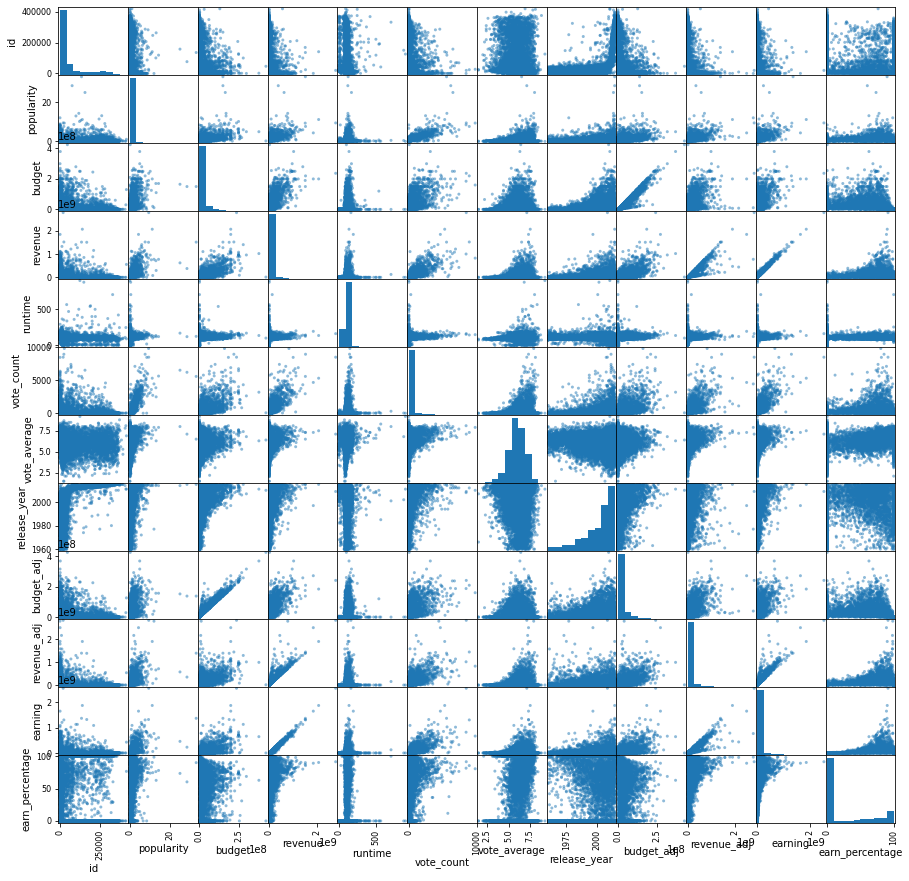

```python
"""
Through this section, we explore our finding.

"""
pd.plotting.scatter_matrix(df, figsize=(15, 15));
```

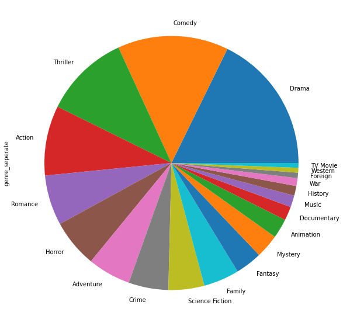

```python
"""
Majority of generes in dataset
"""

df_genres['genre_seperate'].value_counts().plot(kind='pie',figsize=(10,10));
```

### Research Question : Which genres are most popular from year to year?

```python
"""
    As shown below, The grouping of all generes all over the years in the data set
"""
df_genres.groupby('release_year')['genre_seperate'].value_counts().nlargest(30)
```

```
release_year  genre_seperate
2014          Drama             284
2015          Drama             260
2013          Drama             253
2008          Drama             232
2012          Drama             231
2009          Drama             222
2011          Drama             213
2010          Drama             209
2009          Comedy            198
2007          Drama             197
2006          Drama             196
2014          Comedy            183
2005          Drama             182
2014          Thriller          178
```

[output cut: 17 more lines]

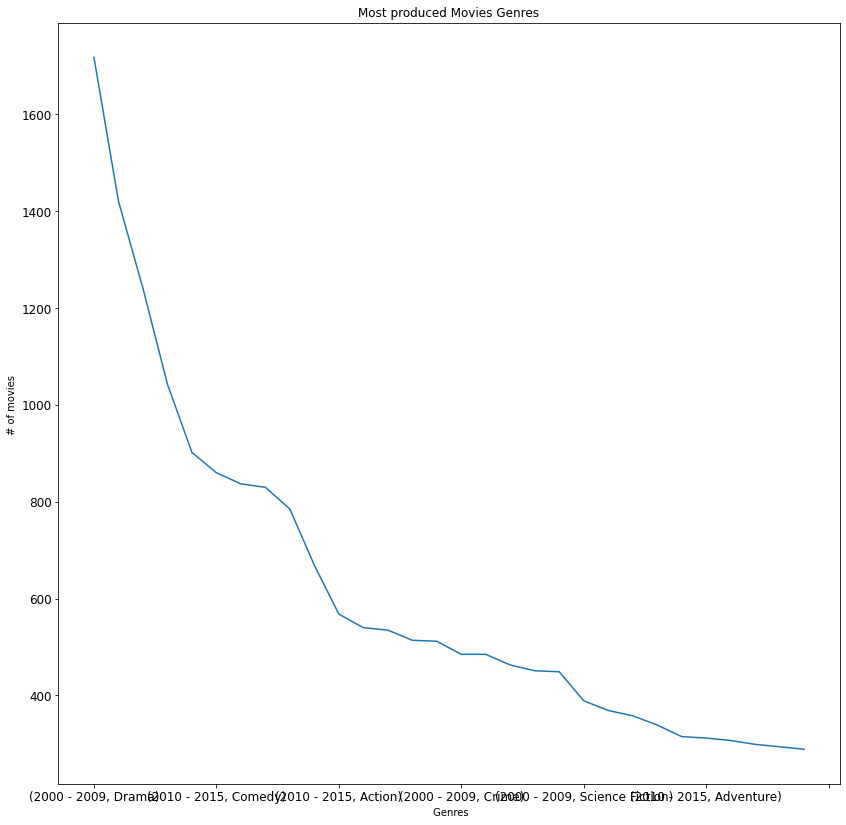

```python
"""
Top 30 generes in period between 1960 to 2015
"""

df_genres.groupby('period').agg('genre_seperate').value_counts().nlargest(30).plot(kind='line', figsize=(14,14), title='Most produced Movies Genres', ylabel='# of movies ', xlabel=' Genres', fontsize=12);

### Research Question : What are the top 20 movies of earning?
```

```python
"""
Answer for most 20 earning movies in the dataset
"""
df[['earning', 'original_title']].sort_values(by='earning', ascending=False).head(20)
```

|  | earning | original_title |
| --- | --- | --- |
| 1386 | 2544505847 | Avatar |
| 3 | 1868178225 | Star Wars: The Force Awakens |
| 5231 | 1645034188 | Titanic |
| 0 | 1363528810 | Jurassic World |
| 4 | 1316249360 | Furious 7 |
| 4361 | 1299557910 | The Avengers |
| 3374 | 1202817822 | Harry Potter and the Deathly Hallows: Part 2 |
| 14 | 1125035767 | Avengers: Age of Ultron |
| 5422 | 1124219009 | Frozen |
| 8094 | 1084279658 | The Net |
| 8 | 1082730962 | Minions |
| 4949 | 1024888979 | The Lord of the Rings: The Return of the King |
| 5425 | 1015439994 | Iron Man 3 |
| 3522 | 928746996 | Transformers: Dark of the Moon |
| 4365 | 908561013 | Skyfall |
| 5434 | 894761885 | Despicable Me 2 |
| 6555 | 865659812 | Pirates of the Caribbean: Dead Man's Chest |
| 1930 | 863171911 | Toy Story 3 |
| 10223 | 857100000 | Jurassic Park |
| 2634 | 851475550 | Harry Potter and the Philosopher's Stone |

### Research Question: What is the correlation between runtime over years?

[figure not shown]

```python
"""
Releationship between runtime all over the hears, it appears as in decreasing matter
"""
df_genres.groupby('period')['runtime'].mean().plot(figsize=(8,8), title='Run Time Scale all over production years', ylabel='Run time in minutes ', xlabel=' Period ', fontsize=12);
```

```python
"""
the most popoular 20 genres in the data set
"""
df_genres[['popularity', 'genre_seperate']].sort_values(by='popularity', ascending=False).head(20)
```

|  | popularity | genre_seperate |
| --- | --- | --- |
| 0 | 32.985763 | Action |
| 0 | 32.985763 | Thriller |
| 0 | 32.985763 | Adventure |
| 0 | 32.985763 | Science Fiction |
| 1 | 28.419936 | Adventure |
| 1 | 28.419936 | Science Fiction |
| 1 | 28.419936 | Thriller |
| 1 | 28.419936 | Action |
| 629 | 24.949134 | Adventure |
| 629 | 24.949134 | Drama |
| 629 | 24.949134 | Science Fiction |
| 630 | 14.311205 | Action |
| 630 | 14.311205 | Adventure |
| 630 | 14.311205 | Science Fiction |
| 2 | 13.112507 | Adventure |
| 2 | 13.112507 | Science Fiction |
| 2 | 13.112507 | Thriller |
| 631 | 12.971027 | Science Fiction |
| 631 | 12.971027 | Action |
| 631 | 12.971027 | Adventure |

### Research Question : What is the average Earnings % over years?

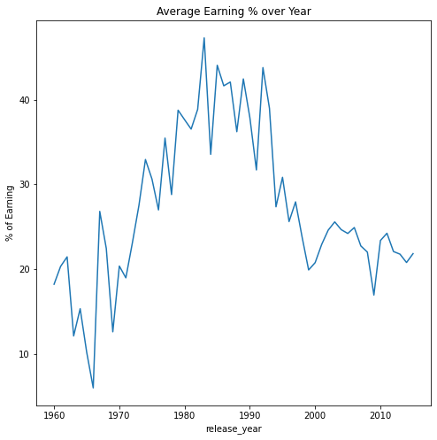

```python
"""
the average earning percentage in the data set over the years
"""

df.groupby('release_year')['earn_percentage'].mean().plot(kind='line', title='Average Earning % over Year', ylabel='% of Earning', figsize=(8,8));
```

### Research Question: What are the 10 most popular movies?

```python
"""
List the 10 movies between 1960-2015 that are most popular
"""

df[['popularity', 'original_title']].sort_values(by='popularity', ascending=False).head(10)
```

|  | popularity | original_title |
| --- | --- | --- |
| 0 | 32.985763 | Jurassic World |
| 1 | 28.419936 | Mad Max: Fury Road |
| 629 | 24.949134 | Interstellar |
| 630 | 14.311205 | Guardians of the Galaxy |
| 2 | 13.112507 | Insurgent |
| 631 | 12.971027 | Captain America: The Winter Soldier |
| 1329 | 12.037933 | Star Wars |
| 632 | 11.422751 | John Wick |
| 3 | 11.173104 | Star Wars: The Force Awakens |
| 633 | 10.739009 | The Hunger Games: Mockingjay - Part 1 |

### Research Question: What are most genres gain earning?

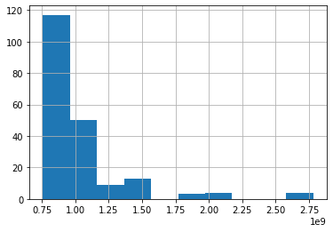

```python
"""
generate the top 200 movies by revenue
"""
df_revenue = df_genres.sort_values(by='revenue', ascending=False).head(200)
df_revenue.describe()
df_revenue.revenue.hist();
```

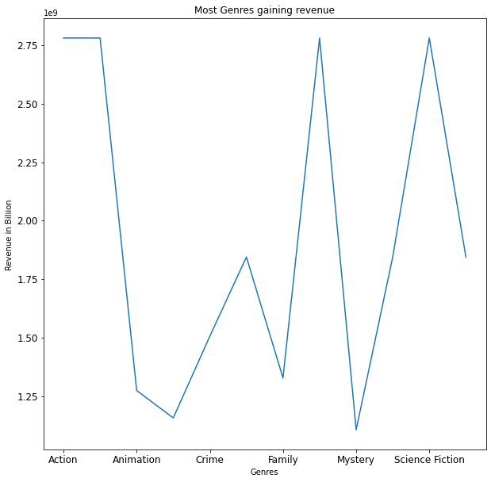

```python
"""
Top generes that gain revenue
"""
df_revenue.groupby('genre_seperate')['revenue'].max().plot(kind='line', figsize=(10,10), title='Most Genres gaining revenue', ylabel='Revenue in Biliion ', xlabel='Genres', fontsize=12);
```

### Research Question: Who is the director that can gain more earning?

```python
"""
show the most directors that able to gain more revenue than others
"""
df[df['earning']>0].groupby('director')['earning'].max().nlargest(10)
```

```
director
James Cameron               2544505847
J.J. Abrams                 1868178225
Colin Trevorrow             1363528810
James Wan                   1316249360
Joss Whedon                 1299557910
David Yates                 1202817822
Chris Buck|Jennifer Lee     1124219009
Irwin Winkler               1084279658
Kyle Balda|Pierre Coffin    1082730962
Peter Jackson               1024888979
Name: earning, dtype: int64
```

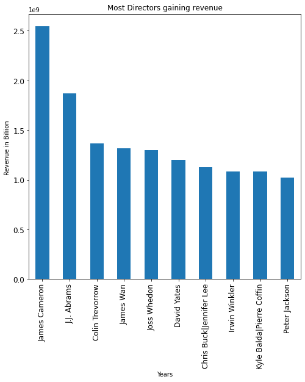

```python
"""
represent the most directors that able to gain more revenue than others in bar graphs
"""
df[df['earning']>0].groupby('director')['earning'].max().nlargest(10).plot(kind='bar', figsize=(8,8), title='Most Directors gaining revenue', ylabel='Revenue in Biliion ', xlabel='Years', fontsize=12);
```

### Research Question: Is Revenue over years increased?

[figure not shown]

```python
"""
Show the revenue increase between years 1960 to 2015
"""

df.groupby('release_year')['revenue'].max().plot(kind='bar',figsize=(16,16),title='Revenue scale between 1960 to 2015', ylabel='Revenue in Biliion ', xlabel='Years', fontsize=12);
```

### Research Question : What are the most produced geners over years ?

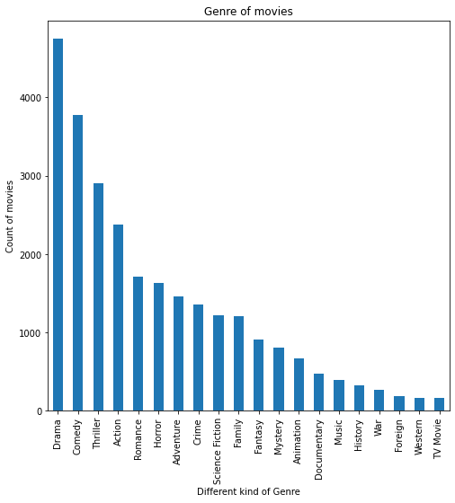

```python
"""
the most generes are representing in below bar graph
"""

df_genres['genre_seperate'].value_counts().plot(kind='bar',figsize=(8,8), title='Genre of movies', ylabel='Count of movies', xlabel='Different kind of Genre');
```

## Limitations

> 1. As the data for old movies is not fully provided for budjet and revenue features. This will affact on the accuracy of the results.
> 2. I have added some values to solve the issue of revenue = 0. This will facilitate the calculation of earning feature
> 3. There is no much information about technology, it's was just a site added to the fields
> 4. The file that is used already has the solution for most of issues related to:
>    - lower case / no spaces fields names
>    - release year already extracted from release date
>    - most of values in a well format, with proper type